# Assessing injury on GOM cetaceans

# 1 Preamble

This is an Electronic Supplement to the manuscript Marques et al. “Quantifying Deepwater Horizon oil spill induced injury on pelagic cetaceans”.

The master file containing links to all supplementary files related to this paper is this Electronic Supplements master file.

If you make use of any of this material in your work, it would be appreciated if you would contact Tiago Marques to let him know.

# 2 Introduction

In this document we present the results of the age, sex and class structured model implemented for all species/stock in the GOM.

We report here the injury metrics originally considered in Schwacke et al. (2017): (1) lost cetacean years (LCY), the difference between the baseline and injured population sizes, summed over the entire modeled time period; (2) years to recovery (YTR), the number of years required before the injured population trajectory reaches 95% of the baseline population trajectory; and (3) maximum proportional decrease (MPD), the difference between the 2 population trajectories when the injured trajectory is at its lowest point, divided by the baseline. Note that LCY is intuitively the metric that is most dependent on initial population size.

# 3 Running the simulations

The code below runs the simulations for all species, and stores the results in appropriate files, stored in appropriate species specific folders. The code below is for completeness only, and IS NOT, AND SHOULD NOT BE, run when this dynamic report is produced.

```r
#define the species we run simulations for
Sps <- c("Bwsp", "Fatt", "Ggri", "Gmac", "Kosp", "Pele", "Pmac", "Satt", "Sbre", "Scly", "Scoe", "Sfro", "Slon", "Ttro", "Ttrs")
#define the number of iterations to run
ns <- 10000
# define the number of years each iteration is run for
ny <- 75
```

```r
# this runs all the simulations and produces outputs for all species
# this code chuck is a separate file: "RunAllSims.R"
# that is the file that should be sourced to run the code
# this code is therefore here just for completeness
# DON NOT turn the "eval=FALSE" into "eval=TRUE"
# unless you are willing to wait for many (many!) hours
# (or even days, depending on the "ns" you choose)
# for your dynamic report to compile
source("Functions/reqfuns.R")         # most functions are here
source("Functions/SilerFuns.R")       # Siler model functions are here
source("Functions/runSims.R")         # To run the simulations for all species
for (i in Sps){
  runPopSims(Sp = i, nsims = ns, nyears = ny, seed = 7134672)
}
```

```r
source("Functions/reqfuns.R")         # most functions are here
```

Creating objects to hold summary results:

```r
# Set up a table to hold summary statistics by species
sumres <- data.frame(Sp=Sps, No=NA, peo=NA, LCYo=NA, MPDo=NA, YTRo=NA, Nstart=NA, Nexp=NA, Pexp=NA, LCY=NA, MPD=NA, YTR=NA,  LCYmed=NA, MPDmed=NA, YTRmed=NA)
# Injury metrics and respective 95% quantile-method CI's
injuryCI <- data.frame(Sp=Sps, LCYmed = NA, LCYl = NA, LCYu = NA, MPDmed = NA, MPDl = NA, MPDu = NA, YTRmed = NA, YTRl = NA, YTRu = NA)
# Some relevant inputs (gd gestation duration and sr survival reduction)
inputs <- data.frame(Sp=Sps, gd = NA, sr = NA)
```

The taxonomic units and the corresponding codes considered in this document are:

- Bwsp beaked whales Beaked whales spp
- Fatt pygmy killer whale *Feresa attenuata*
- Ggri Risso’s dolphin *Grampus griseus*
- Gmac short-finned pilot whale *Globicephala macrorhynchus*
- Kosp kogia *Kogia* sp.
- Pele melon-headed whale *Peponocephala electra*
- Pmac sperm whale *Physeter macrocephalus*
- Satt pantropical spotted dolphin *Stenella attenuata*
- Sbre rough-toothed dolphin *Steno bredanensis*
- Scly Clymene dolphin *Stenella clymene*
- Scoe striped dolphin *Stenella coeruleoalba*
- Sfro Atlantic spotted dolphin *Stenella frontalis*
- Slon spinner dolphin *Stenella longirostris*
- Ttro offshore bottlenose dolphins *Tursiops truncatus*
- Ttrs shelf bottlenose dolphins *Tursiops truncatus*

We explicitly re-order the results tables upfront so that results are organized by alphabetical order of the 4 letter code used to describe the taxonomic unit (this is also the order that the species are reported in tables 1 to 3 of the offshore paper).

```r
# note there is no effect if Sps is already in alphabetical order
# but it is here to make sure that this code will work even if
# the vector Sps is changed
injuryCI <- injuryCI[order(Sps),]
sumres <- sumres[order(Sps),]
inputs <- inputs[order(Sps),]
```

Note that the initial population sizes and proportion exposed shown below are obtained after removing the very rare instances where the population size would be considered too large to be reasonable. This is imported from a `txt` file produced inside IniPopSizes. See IniPopSizes and the main paper for details on this choice.

```r
IniPopSizes <- read.table(file = "Table4GetInjury.txt",header=TRUE)
IniPopSizes <- IniPopSizes[order(Sps),]
```

# 4 Results by species

We represent in turn, for each species, the simulated population trajectories under the oil spill and under the baseline scenarios, as well as the histograms of the distributions of the 3 injury metrics for each species.

## 4.1 *Physeter macrocephalus* (Pmac, sperm whale)

```r
gc();Sp <- "Pmac"
```

```
##          used (Mb) gc trigger (Mb) max used (Mb)
## Ncells 469010 25.1    1020558 54.6   638940 34.2
## Vcells 854579  6.6    8388608 64.0  1633877 12.5
```

```r
SpInfo <- getSpData(Sp)
load(file=paste0("InOutBySp/", SpInfo$folder, "/", Sp, "simres", ns, "Sim.RData"))
inputs$gd[inputs$Sp==Sp] <- SpInfo$gd
inputs$sr[inputs$Sp==Sp] <- with(SpInfo, mean(rbeta(10000, sra, srb)*(sru-srl)+srl))
```

Population trajectories

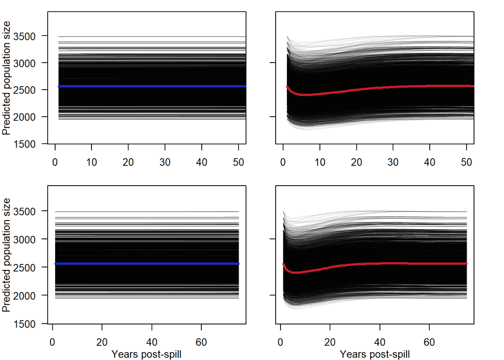

```r
plotSims(simres)
```

Injury measures

```r
x <- getInjury(simres)
```

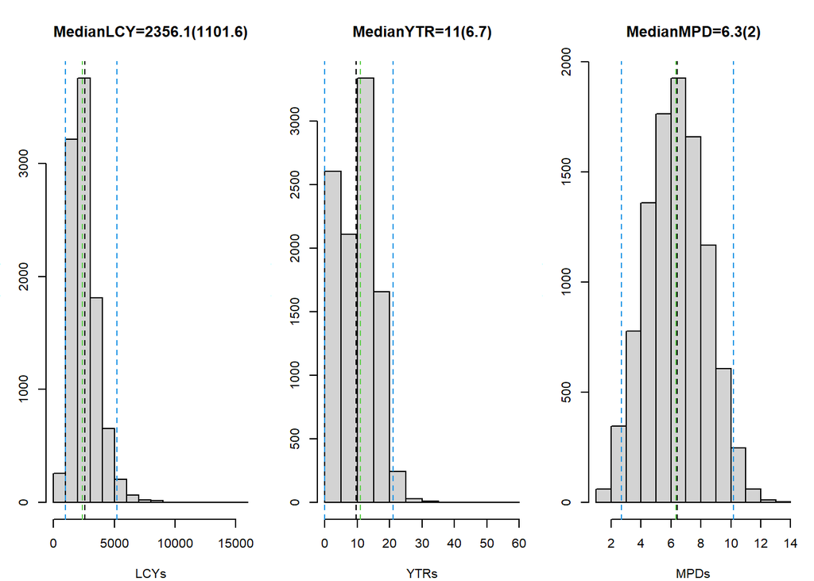

```r
colMeans(injury)
```

```
##         LCY         YTR         MPD
## 2549.139215    9.725500    6.375102
```

```r
apply(injury, 2, median)
```

```
##         LCY         YTR         MPD
## 2356.117334   11.000000    6.343538
```

Collect information to summary table

```r
sumres[sumres$Sp==Sp, 2:15]<-c(SpInfo$N, SpInfo$pe, SpInfo$LCY, SpInfo$MPD, SpInfo$YTR, IniPopSizes$N[IniPopSizes$Sp==Sp], IniPopSizes$Ne[IniPopSizes$Sp==Sp], IniPopSizes$Pe[IniPopSizes$Sp==Sp], mean(injury$LCY), mean(injury$MPD), mean(injury$YTR),  median(injury$LCY), median(injury$MPD), median(injury$YTR))
```

and collect information to injury summary table

```r
injuryCI[injuryCI$Sp==Sp, 2:10]<-c(median(injury$LCY), quantile(injury$LCY, probs=c(0.025,0.975)), median(injury$MPD), quantile(injury$MPD, probs = c(0.025, 0.975)), median(injury$YTR), quantile(injury$YTR,probs = c(0.025, 0.975)))
```

## 4.2 *Kogia* sp. (Kosp, kogia)

```r
gc();Sp <- "Kosp"
```

```
##             used   (Mb) gc trigger    (Mb)   max used   (Mb)
## Ncells    689520   36.9    7464516   398.7    9330644  498.4
## Vcells 712630175 5437.0 1540598814 11753.9 1247685648 9519.1
```

```r
SpInfo <- getSpData(Sp)
load(file=paste0("InOutBySp/", SpInfo$folder, "/", Sp, "simres", ns, "Sim.RData"))
inputs$gd[inputs$Sp==Sp] <- SpInfo$gd
inputs$sr[inputs$Sp==Sp] <- with(SpInfo, mean(rbeta(10000, sra, srb)*(sru-srl)+srl))
```

Population trajectories

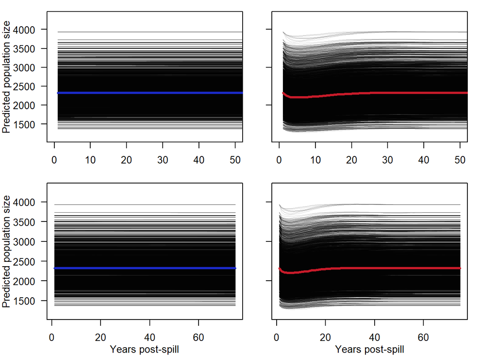

```r
plotSims(simres)
```

Injury measures

```r
x <- getInjury(simres)
```

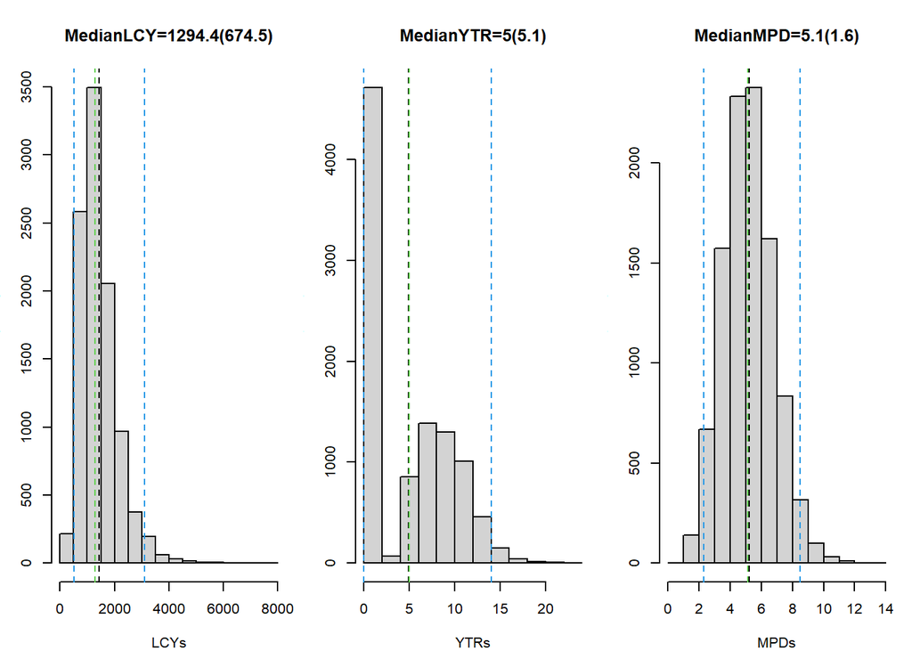

```r
colMeans(injury)
```

```
##         LCY         YTR         MPD
## 1429.418506    4.898900    5.185119
```

```r
apply(injury, 2, median)
```

```
##         LCY         YTR         MPD
## 1294.396670    5.000000    5.114312
```

Collect information to summary table

```r
sumres[sumres$Sp==Sp, 2:15]<-c(SpInfo$N, SpInfo$pe, SpInfo$LCY, SpInfo$MPD, SpInfo$YTR, IniPopSizes$N[IniPopSizes$Sp==Sp], IniPopSizes$Ne[IniPopSizes$Sp==Sp], IniPopSizes$Pe[IniPopSizes$Sp==Sp], mean(injury$LCY), mean(injury$MPD), mean(injury$YTR),  median(injury$LCY), median(injury$MPD), median(injury$YTR))
```

and collect information to injury summary table

```r
injuryCI[injuryCI$Sp==Sp, 2:10]<-c(median(injury$LCY), quantile(injury$LCY, probs=c(0.025,0.975)), median(injury$MPD), quantile(injury$MPD, probs = c(0.025, 0.975)), median(injury$YTR), quantile(injury$YTR,probs = c(0.025, 0.975)))
```

## 4.3 *Stenella clymene* (Scly, Clymene dolphin)

```r
gc();Sp <- "Scly"
```

```
##             used   (Mb) gc trigger    (Mb)   max used    (Mb)
## Ncells    689388   36.9    5764748   307.9    9330644   498.4
## Vcells 514630025 3926.4 1540598814 11753.9 1485518871 11333.7
```

```r
SpInfo <- getSpData(Sp)
load(file=paste0("InOutBySp/", SpInfo$folder, "/", Sp, "simres", ns, "Sim.RData"))
inputs$gd[inputs$Sp==Sp] <- SpInfo$gd
inputs$sr[inputs$Sp==Sp] <- with(SpInfo, mean(rbeta(10000, sra, srb)*(sru-srl)+srl))
```

Population trajectories

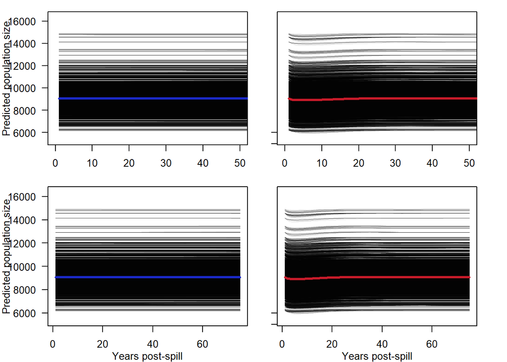

```r
plotSims(simres)
```

Injury measures

```r
x <- getInjury(simres)
```

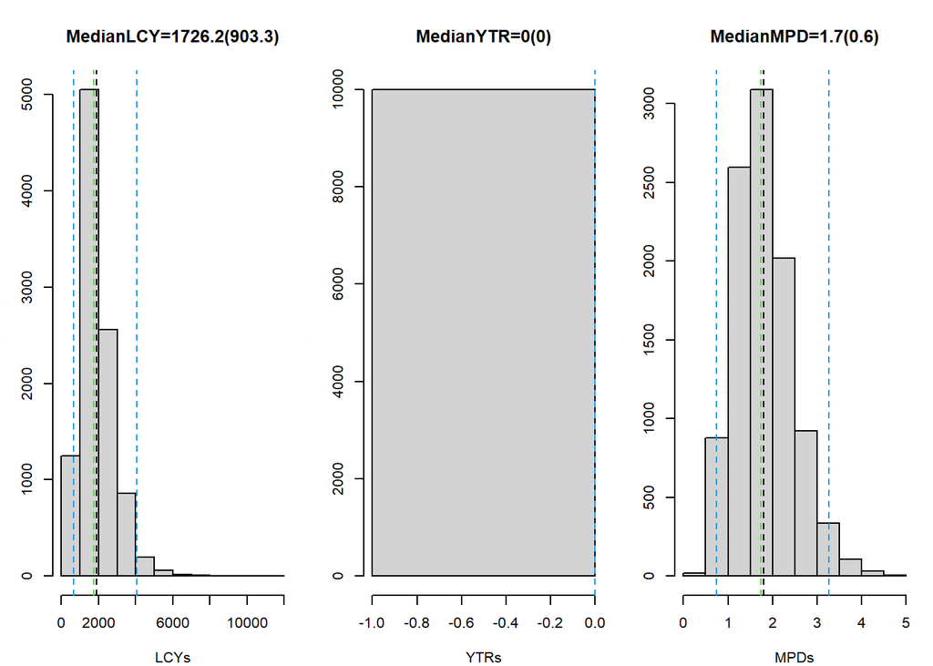

```r
colMeans(injury)
```

```
##         LCY         YTR         MPD
## 1901.525708    0.000000    1.801292
```

```r
apply(injury, 2, median)
```

```
##         LCY         YTR         MPD
## 1726.224739    0.000000    1.734413
```

Collect information to summary table

```r
sumres[sumres$Sp==Sp, 2:15]<-c(SpInfo$N, SpInfo$pe, SpInfo$LCY, SpInfo$MPD, SpInfo$YTR, IniPopSizes$N[IniPopSizes$Sp==Sp], IniPopSizes$Ne[IniPopSizes$Sp==Sp], IniPopSizes$Pe[IniPopSizes$Sp==Sp], mean(injury$LCY), mean(injury$MPD), mean(injury$YTR),  median(injury$LCY), median(injury$MPD), median(injury$YTR))
```

and collect information to injury summary table

```r
injuryCI[injuryCI$Sp==Sp, 2:10]<-c(median(injury$LCY), quantile(injury$LCY, probs=c(0.025,0.975)), median(injury$MPD), quantile(injury$MPD, probs = c(0.025, 0.975)), median(injury$YTR), quantile(injury$YTR,probs = c(0.025, 0.975)))
```

## 4.4 *Peponocephala electra* (Pele, melon-headed whale)

```r
gc();Sp <- "Pele"
```

```
##             used   (Mb) gc trigger    (Mb)   max used    (Mb)
## Ncells    689391   36.9    6916897   369.5    9330644   498.4
## Vcells 514630150 3926.4 1540598814 11753.9 1485518871 11333.7
```

```r
SpInfo <- getSpData(Sp)
load(file=paste0("InOutBySp/", SpInfo$folder, "/", Sp, "simres", ns, "Sim.RData"))
inputs$gd[inputs$Sp==Sp] <- SpInfo$gd
inputs$sr[inputs$Sp==Sp] <- with(SpInfo, mean(rbeta(10000, sra, srb)*(sru-srl)+srl))
```

Population trajectories

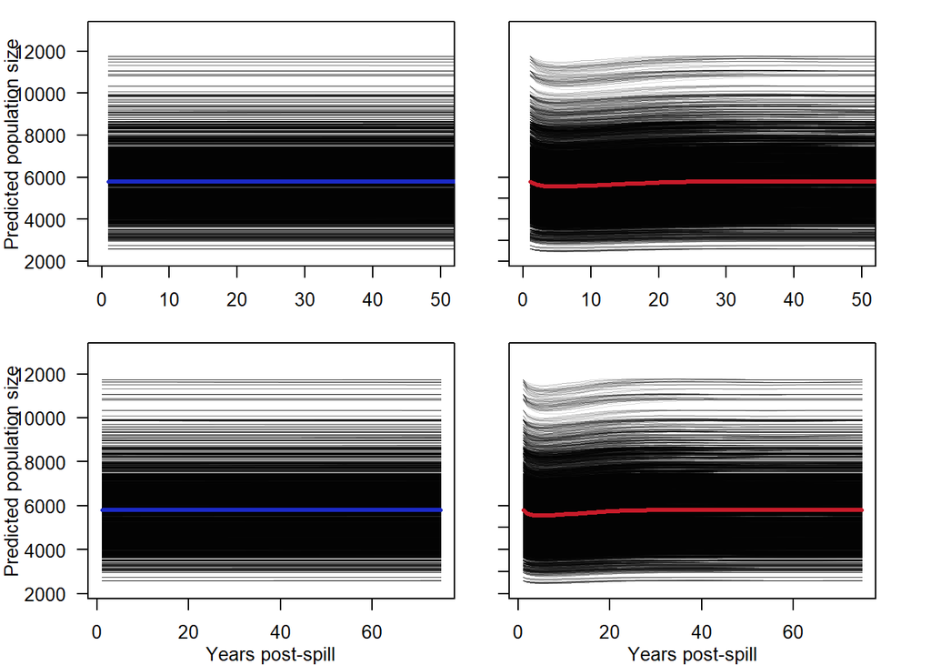

```r
plotSims(simres)
```

Injury measures

```r
x <- getInjury(simres)
```

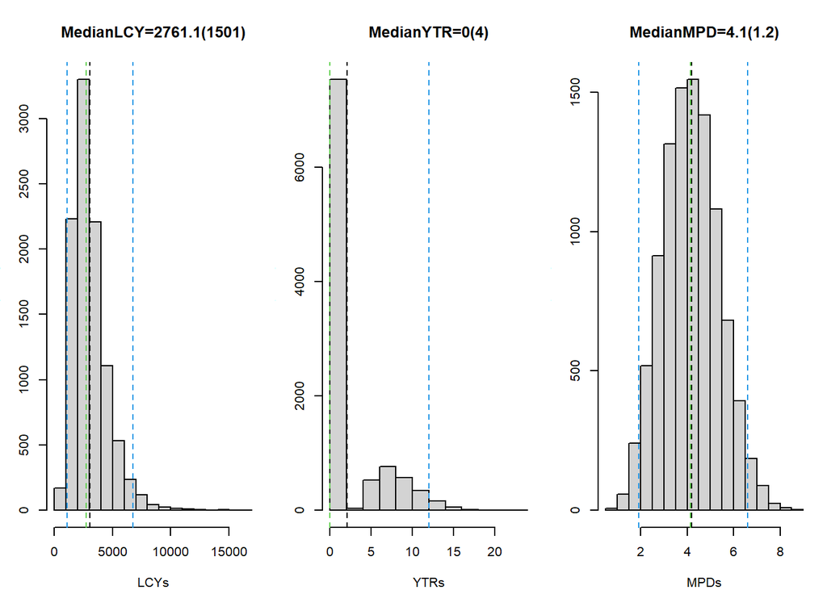

```r
colMeans(injury)
```

```
##         LCY         YTR         MPD
## 3071.523882    2.137900    4.168256
```

```r
apply(injury, 2, median)
```

```
##         LCY         YTR         MPD
## 2761.091982    0.000000    4.140491
```

Collect information to summary table

```r
sumres[sumres$Sp==Sp, 2:15]<-c(SpInfo$N, SpInfo$pe, SpInfo$LCY, SpInfo$MPD, SpInfo$YTR, IniPopSizes$N[IniPopSizes$Sp==Sp], IniPopSizes$Ne[IniPopSizes$Sp==Sp], IniPopSizes$Pe[IniPopSizes$Sp==Sp], mean(injury$LCY), mean(injury$MPD), mean(injury$YTR),  median(injury$LCY), median(injury$MPD), median(injury$YTR))
```

and collect information to injury summary table

```r
injuryCI[injuryCI$Sp==Sp, 2:10]<-c(median(injury$LCY), quantile(injury$LCY, probs=c(0.025,0.975)), median(injury$MPD), quantile(injury$MPD, probs = c(0.025, 0.975)), median(injury$YTR), quantile(injury$YTR,probs = c(0.025, 0.975)))
```

## 4.5 *Tursiops truncatus* (Ttro, offshore bottlenose dolphin)

```r
gc();Sp <- "Ttro"
```

```
##             used   (Mb) gc trigger    (Mb)   max used    (Mb)
## Ncells    689430   36.9    5344177   285.5    9330644   498.4
## Vcells 568630343 4338.4 1540598814 11753.9 1485518871 11333.7
```

```r
SpInfo <- getSpData(Sp)
load(file=paste0("InOutBySp/", SpInfo$folder, "/", Sp, "simres", ns, "Sim.RData"))
inputs$gd[inputs$Sp==Sp] <- SpInfo$gd
inputs$sr[inputs$Sp==Sp] <- with(SpInfo, mean(rbeta(10000, sra, srb)*(sru-srl)+srl))
```

Population trajectories

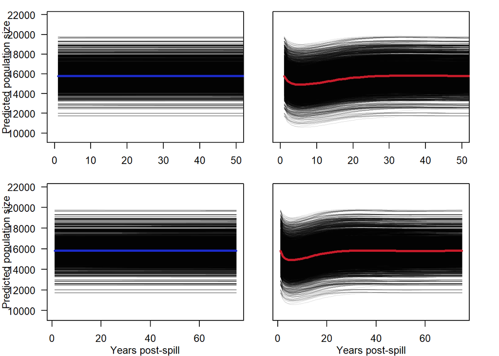

```r
plotSims(simres)
```

Injury measures

```r
x <- getInjury(simres)
```

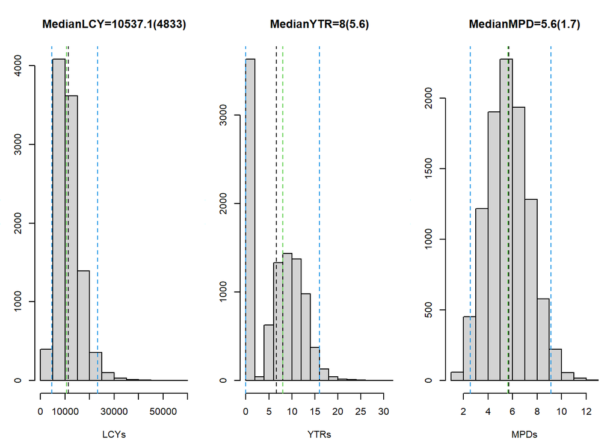

```r
colMeans(injury)
```

```
##          LCY          YTR          MPD
## 11369.564397     6.586900     5.658282
```

```r
apply(injury, 2, median)
```

```
##          LCY          YTR          MPD
## 10537.111729     8.000000     5.609857
```

Collect information to summary table

```r
sumres[sumres$Sp==Sp, 2:15]<-c(SpInfo$N, SpInfo$pe, SpInfo$LCY, SpInfo$MPD, SpInfo$YTR, IniPopSizes$N[IniPopSizes$Sp==Sp], IniPopSizes$Ne[IniPopSizes$Sp==Sp], IniPopSizes$Pe[IniPopSizes$Sp==Sp], mean(injury$LCY), mean(injury$MPD), mean(injury$YTR),  median(injury$LCY), median(injury$MPD), median(injury$YTR))
```

and collect information to injury summary table

```r
injuryCI[injuryCI$Sp==Sp, 2:10]<-c(median(injury$LCY), quantile(injury$LCY, probs=c(0.025,0.975)), median(injury$MPD), quantile(injury$MPD, probs = c(0.025, 0.975)), median(injury$YTR), quantile(injury$YTR,probs = c(0.025, 0.975)))
```

## 4.6 *Globicephala macrorhynchus* (Gmac, short finned pilot whale)

```r
gc();Sp <- "Gmac"
```

```
##             used   (Mb) gc trigger    (Mb)   max used    (Mb)
## Ncells    689421   36.9    6534495   349.0    9330644   498.4
## Vcells 550630440 4201.0 1540598814 11753.9 1485518871 11333.7
```

```r
SpInfo <- getSpData(Sp)
load(file=paste0("InOutBySp/", SpInfo$folder, "/", Sp, "simres", ns, "Sim.RData"))
inputs$gd[inputs$Sp==Sp] <- SpInfo$gd
inputs$sr[inputs$Sp==Sp] <- with(SpInfo, mean(rbeta(10000, sra, srb)*(sru-srl)+srl))
```

Population trajectories

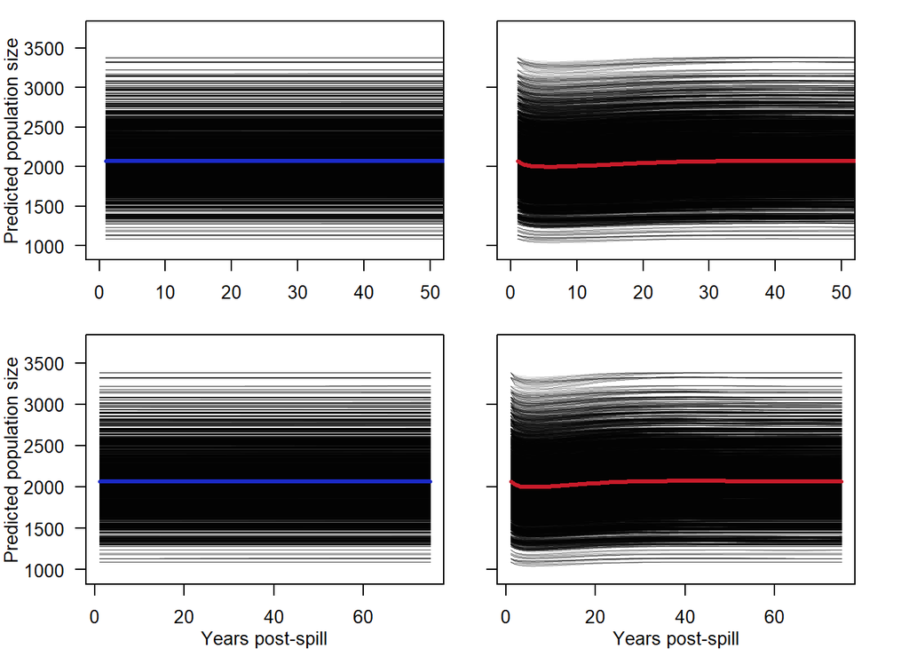

```r
plotSims(simres)
```

Injury measures

```r
x <- getInjury(simres)
```

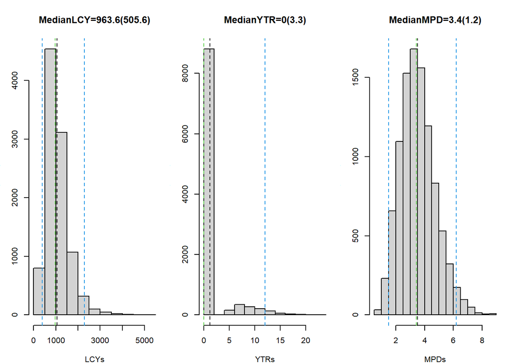

```r
colMeans(injury)
```

```
##         LCY         YTR         MPD
## 1057.863912    1.156400    3.538044
```

```r
apply(injury, 2, median)
```

```
##        LCY        YTR        MPD
## 963.644195   0.000000   3.435437
```

Collect information to summary table

```r
sumres[sumres$Sp==Sp, 2:15]<-c(SpInfo$N, SpInfo$pe, SpInfo$LCY, SpInfo$MPD, SpInfo$YTR, IniPopSizes$N[IniPopSizes$Sp==Sp], IniPopSizes$Ne[IniPopSizes$Sp==Sp], IniPopSizes$Pe[IniPopSizes$Sp==Sp], mean(injury$LCY), mean(injury$MPD), mean(injury$YTR),  median(injury$LCY), median(injury$MPD), median(injury$YTR))
```

and collect information to injury summary table

```r
injuryCI[injuryCI$Sp==Sp, 2:10]<-c(median(injury$LCY), quantile(injury$LCY, probs=c(0.025,0.975)), median(injury$MPD), quantile(injury$MPD, probs = c(0.025, 0.975)), median(injury$YTR), quantile(injury$YTR,probs = c(0.025, 0.975)))
```

## 4.7 *Feresa attenuata* (Fatt, pygmy killer whale)

```r
gc();Sp <- "Fatt"
```

```
##             used   (Mb) gc trigger    (Mb)   max used    (Mb)
## Ncells    689502   36.9   10286607   549.4   12858258   686.8
## Vcells 667630712 5093.7 1540598814 11753.9 1540572524 11753.7
```

```r
SpInfo <- getSpData(Sp)
load(file=paste0("InOutBySp/", SpInfo$folder, "/", Sp, "simres", ns, "Sim.RData"))
inputs$gd[inputs$Sp==Sp] <- SpInfo$gd
inputs$sr[inputs$Sp==Sp] <- with(SpInfo, mean(rbeta(10000, sra, srb)*(sru-srl)+srl))
```

Population trajectories

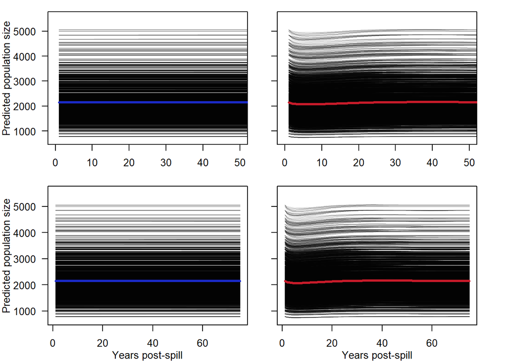

```r
plotSims(simres)
```

Injury measures

```r
x <- getInjury(simres)
```

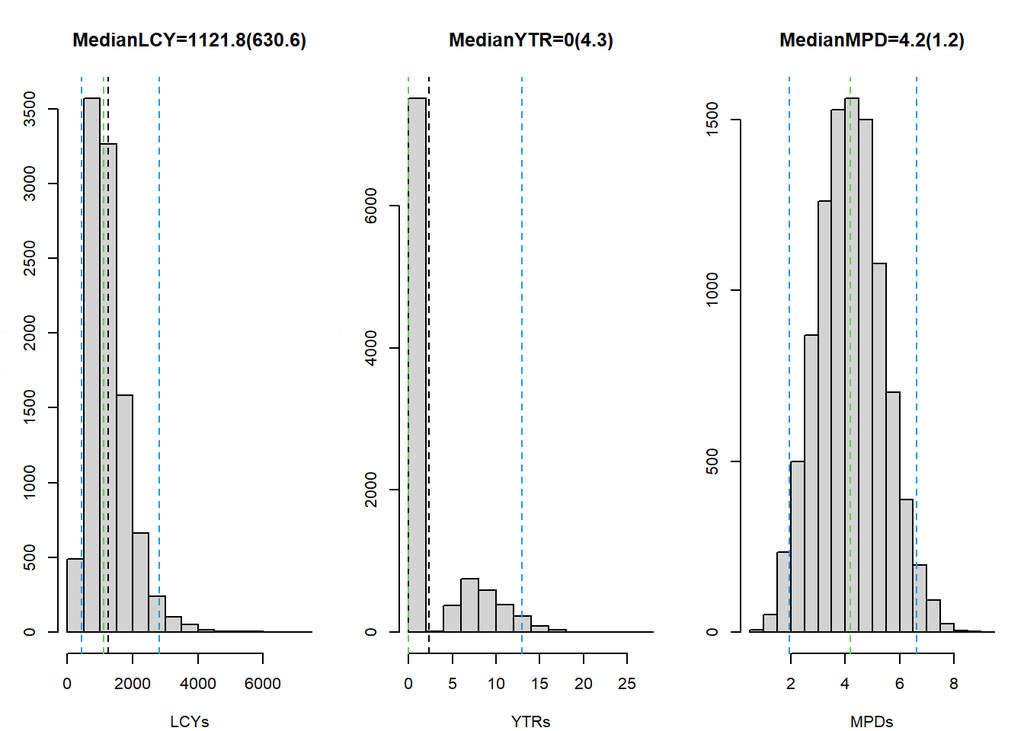

```r
colMeans(injury)
```

```
##         LCY         YTR         MPD
## 1249.503621    2.308200    4.194471
```

```r
apply(injury, 2, median)
```

```
##         LCY         YTR         MPD
## 1121.786078    0.000000    4.186186
```

Collect information to summary table

```r
sumres[sumres$Sp==Sp, 2:15]<-c(SpInfo$N, SpInfo$pe, SpInfo$LCY, SpInfo$MPD, SpInfo$YTR, IniPopSizes$N[IniPopSizes$Sp==Sp], IniPopSizes$Ne[IniPopSizes$Sp==Sp], IniPopSizes$Pe[IniPopSizes$Sp==Sp], mean(injury$LCY), mean(injury$MPD), mean(injury$YTR),  median(injury$LCY), median(injury$MPD), median(injury$YTR))
```

and collect information to injury summary table

```r
injuryCI[injuryCI$Sp==Sp, 2:10]<-c(median(injury$LCY), quantile(injury$LCY, probs=c(0.025,0.975)), median(injury$MPD), quantile(injury$MPD, probs = c(0.025, 0.975)), median(injury$YTR), quantile(injury$YTR,probs = c(0.025, 0.975)))
```

## 4.8 *Grampus griseus* (Ggri, Risso’s dolphin)

```r
gc();Sp <- "Ggri"
```

```
##             used   (Mb) gc trigger    (Mb)   max used    (Mb)
## Ncells    689478   36.9    6583429   351.6   12858258   686.8
## Vcells 622630776 4750.3 1540598814 11753.9 1540595554 11753.9
```

```r
SpInfo <- getSpData(Sp)
load(file=paste0("InOutBySp/", SpInfo$folder, "/", Sp, "simres", ns, "Sim.RData"))
inputs$gd[inputs$Sp==Sp] <- SpInfo$gd
inputs$sr[inputs$Sp==Sp] <- with(SpInfo, mean(rbeta(10000, sra, srb)*(sru-srl)+srl))
```

Population trajectories

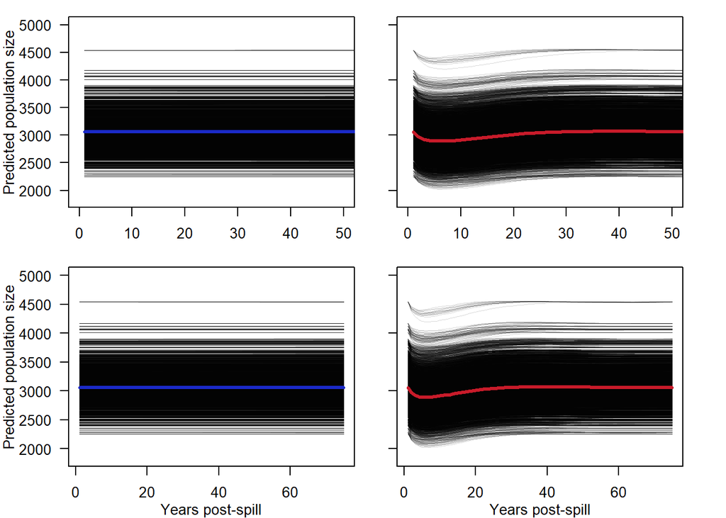

```r
plotSims(simres)
```

Injury measures

```r
x <- getInjury(simres)
```

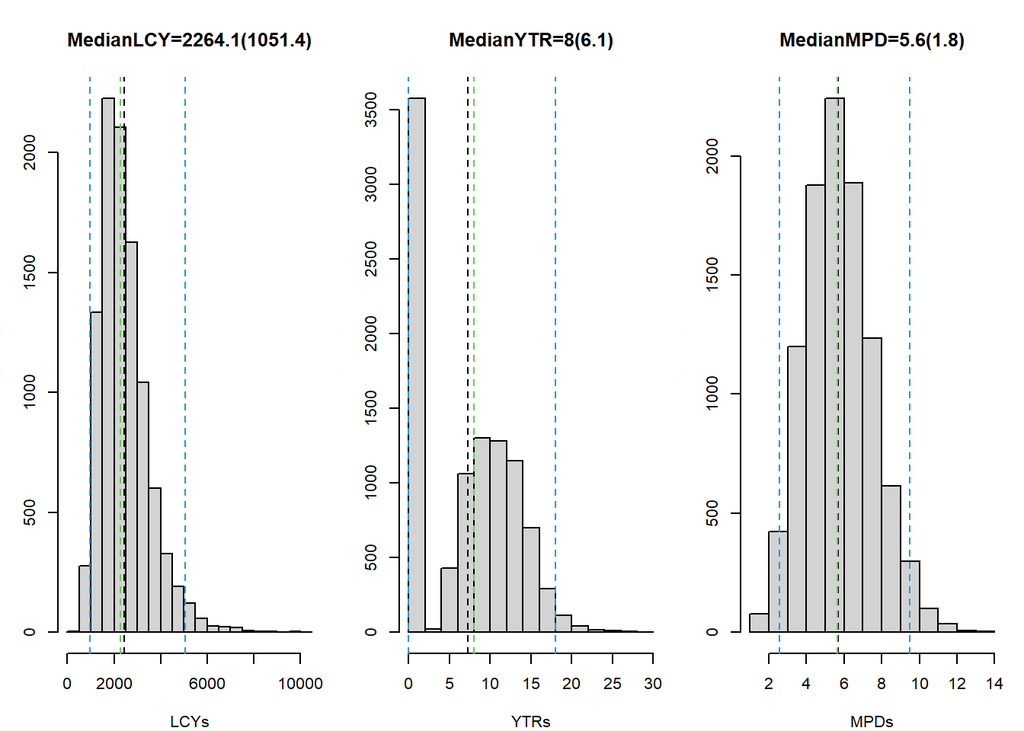

```r
colMeans(injury)
```

```
##         LCY         YTR         MPD
## 2449.136975    7.290900    5.735186
```

```r
apply(injury, 2, median)
```

```
##         LCY         YTR         MPD
## 2264.128121    8.000000    5.623311
```

Collect information to summary table

```r
sumres[sumres$Sp==Sp, 2:15]<-c(SpInfo$N, SpInfo$pe, SpInfo$LCY, SpInfo$MPD, SpInfo$YTR, IniPopSizes$N[IniPopSizes$Sp==Sp], IniPopSizes$Ne[IniPopSizes$Sp==Sp], IniPopSizes$Pe[IniPopSizes$Sp==Sp], mean(injury$LCY), mean(injury$MPD), mean(injury$YTR),  median(injury$LCY), median(injury$MPD), median(injury$YTR))
```

and collect information to injury summary table

```r
injuryCI[injuryCI$Sp==Sp, 2:10]<-c(median(injury$LCY), quantile(injury$LCY, probs=c(0.025,0.975)), median(injury$MPD), quantile(injury$MPD, probs = c(0.025, 0.975)), median(injury$YTR), quantile(injury$YTR,probs = c(0.025, 0.975)))
```

## 4.9 *Steno bredanensis* (Sbre, rough-toothed dolphin)

```r
gc();Sp <- "Sbre"
```

```
##             used   (Mb) gc trigger    (Mb)   max used    (Mb)
## Ncells    689472   36.9    6832984   365.0   12858258   686.8
## Vcells 613630878 4681.7 1540598814 11753.9 1540595554 11753.9
```

```r
SpInfo <- getSpData(Sp)
load(file=paste0("InOutBySp/", SpInfo$folder, "/", Sp, "simres", ns, "Sim.RData"))
inputs$gd[inputs$Sp==Sp] <- SpInfo$gd
inputs$sr[inputs$Sp==Sp] <- with(SpInfo, mean(rbeta(10000, sra, srb)*(sru-srl)+srl))
```

Population trajectories

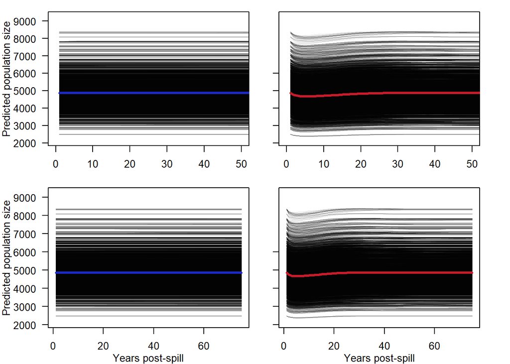

```r
plotSims(simres)
```

Injury measures

```r
x <- getInjury(simres)
```

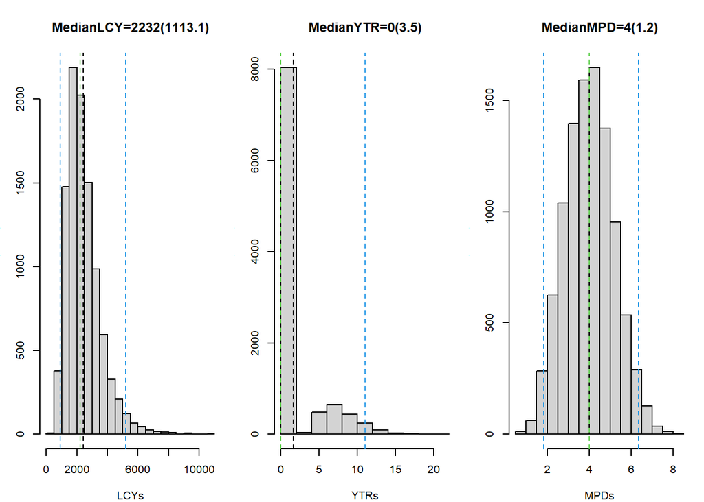

```r
colMeans(injury)
```

```
##         LCY         YTR         MPD
## 2434.417513    1.640900    4.006926
```

```r
apply(injury, 2, median)
```

```
##         LCY         YTR         MPD
## 2232.030151    0.000000    3.994899
```

Collect information to summary table

```r
sumres[sumres$Sp==Sp, 2:15]<-c(SpInfo$N, SpInfo$pe, SpInfo$LCY, SpInfo$MPD, SpInfo$YTR, IniPopSizes$N[IniPopSizes$Sp==Sp], IniPopSizes$Ne[IniPopSizes$Sp==Sp], IniPopSizes$Pe[IniPopSizes$Sp==Sp], mean(injury$LCY), mean(injury$MPD), mean(injury$YTR),  median(injury$LCY), median(injury$MPD), median(injury$YTR))
```

and collect information to injury summary table

```r
injuryCI[injuryCI$Sp==Sp, 2:10]<-c(median(injury$LCY), quantile(injury$LCY, probs=c(0.025,0.975)), median(injury$MPD), quantile(injury$MPD, probs = c(0.025, 0.975)), median(injury$YTR), quantile(injury$YTR,probs = c(0.025, 0.975)))
```

## 4.10 *Stenella attenuata* (Satt, pantropical spotted dolphin)

```r
gc();Sp <- "Satt"
```

```
##             used   (Mb) gc trigger    (Mb)   max used    (Mb)
## Ncells    689439   36.9    6696670   357.7   12858258   686.8
## Vcells 559630927 4269.7 1540598814 11753.9 1540595554 11753.9
```

```r
SpInfo <- getSpData(Sp)
load(file=paste0("InOutBySp/", SpInfo$folder, "/", Sp, "simres", ns, "Sim.RData"))
inputs$gd[inputs$Sp==Sp] <- SpInfo$gd
inputs$sr[inputs$Sp==Sp] <- with(SpInfo, mean(rbeta(10000, sra, srb)*(sru-srl)+srl))
```

Population trajectories

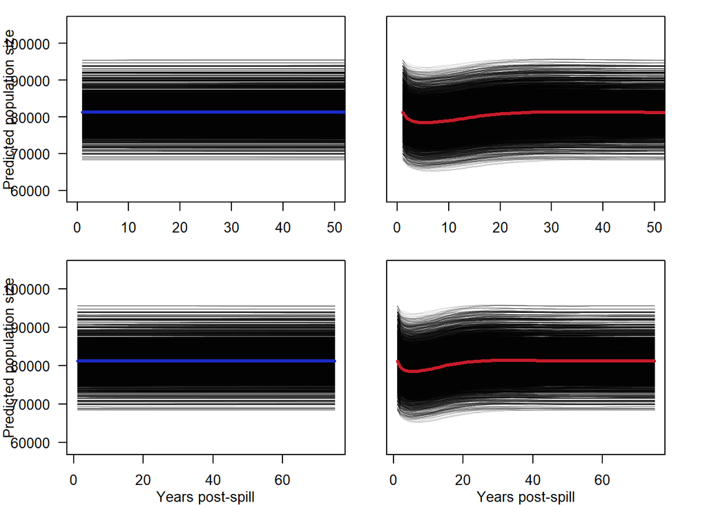

```r
plotSims(simres)
```

Injury measures

```r
x <- getInjury(simres)
```

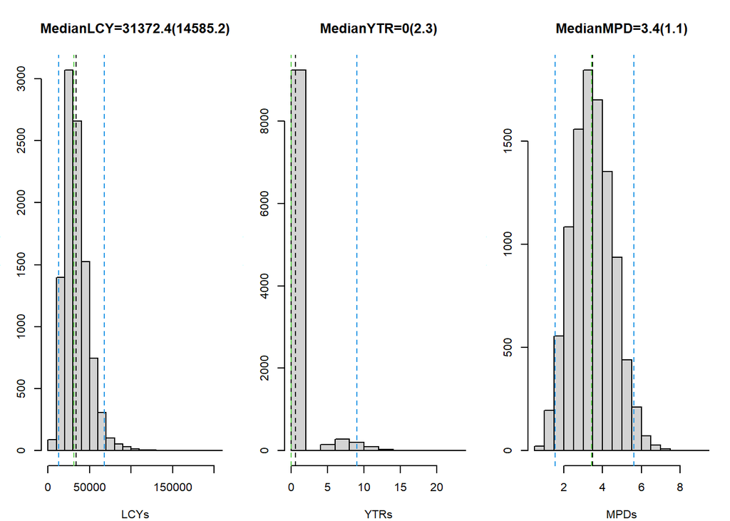

```r
colMeans(injury)
```

```
##          LCY          YTR          MPD
## 33809.632317     0.635700     3.474522
```

```r
apply(injury, 2, median)
```

```
##          LCY          YTR          MPD
## 31372.446670     0.000000     3.433361
```

Collect information to summary table

```r
sumres[sumres$Sp==Sp, 2:15]<-c(SpInfo$N, SpInfo$pe, SpInfo$LCY, SpInfo$MPD, SpInfo$YTR, IniPopSizes$N[IniPopSizes$Sp==Sp], IniPopSizes$Ne[IniPopSizes$Sp==Sp], IniPopSizes$Pe[IniPopSizes$Sp==Sp], mean(injury$LCY), mean(injury$MPD), mean(injury$YTR),  median(injury$LCY), median(injury$MPD), median(injury$YTR))
```

and collect information to injury summary table

```r
injuryCI[injuryCI$Sp==Sp, 2:10]<-c(median(injury$LCY), quantile(injury$LCY, probs=c(0.025,0.975)), median(injury$MPD), quantile(injury$MPD, probs = c(0.025, 0.975)), median(injury$YTR), quantile(injury$YTR,probs = c(0.025, 0.975)))
```

## 4.11 *Tursiops truncatus* (Ttrs, shelf bottlenose dolphin)

```r
gc();Sp <- "Ttrs"
```

```
##             used   (Mb) gc trigger    (Mb)   max used    (Mb)
## Ncells    689412   36.9    4140035   221.2   12858258   686.8
## Vcells 514630988 3926.4 1540598814 11753.9 1540595554 11753.9
```

```r
SpInfo <- getSpData(Sp)
load(file=paste0("InOutBySp/", SpInfo$folder, "/", Sp, "simres", ns, "Sim.RData"))
inputs$gd[inputs$Sp==Sp] <- SpInfo$gd
inputs$sr[inputs$Sp==Sp] <- with(SpInfo, mean(rbeta(10000, sra, srb)*(sru-srl)+srl))
```

Population trajectories

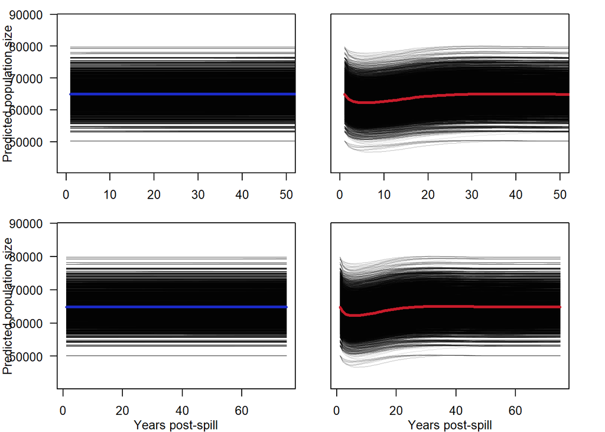

```r
plotSims(simres)
```

Injury measures

```r
x <- getInjury(simres)
```

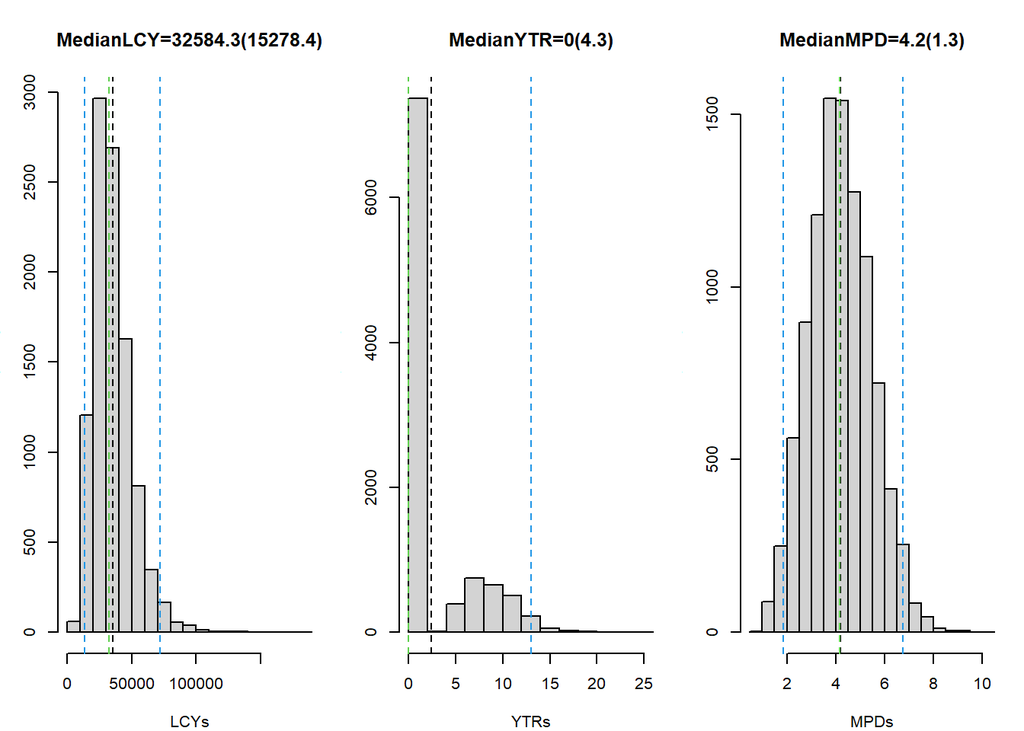

```r
colMeans(injury)
```

```
##          LCY          YTR          MPD
## 35190.477524     2.435900     4.191836
```

```r
apply(injury, 2, median)
```

```
##          LCY          YTR          MPD
## 32584.311004     0.000000     4.152281
```

Collect information to summary table

```r
sumres[sumres$Sp==Sp, 2:15]<-c(SpInfo$N, SpInfo$pe, SpInfo$LCY, SpInfo$MPD, SpInfo$YTR, IniPopSizes$N[IniPopSizes$Sp==Sp], IniPopSizes$Ne[IniPopSizes$Sp==Sp], IniPopSizes$Pe[IniPopSizes$Sp==Sp], mean(injury$LCY), mean(injury$MPD), mean(injury$YTR),  median(injury$LCY), median(injury$MPD), median(injury$YTR))
```

and collect information to injury summary table

```r
injuryCI[injuryCI$Sp==Sp, 2:10]<-c(median(injury$LCY), quantile(injury$LCY, probs=c(0.025,0.975)), median(injury$MPD), quantile(injury$MPD, probs = c(0.025, 0.975)), median(injury$YTR), quantile(injury$YTR,probs = c(0.025, 0.975)))
```

## 4.12 *Stenella longirostris* (Slon, spinner dolphin)

```r
gc();Sp <- "Slon"
```

```
##             used   (Mb) gc trigger    (Mb)   max used    (Mb)
## Ncells    689439   36.9    7611582   406.6   12858258   686.8
## Vcells 550631157 4201.0 1540598814 11753.9 1540595554 11753.9
```

```r
SpInfo <- getSpData(Sp)
load(file=paste0("InOutBySp/", SpInfo$folder, "/", Sp, "simres", ns, "Sim.RData"))
inputs$gd[inputs$Sp==Sp] <- SpInfo$gd
inputs$sr[inputs$Sp==Sp] <- with(SpInfo, mean(rbeta(10000, sra, srb)*(sru-srl)+srl))
```

Population trajectories

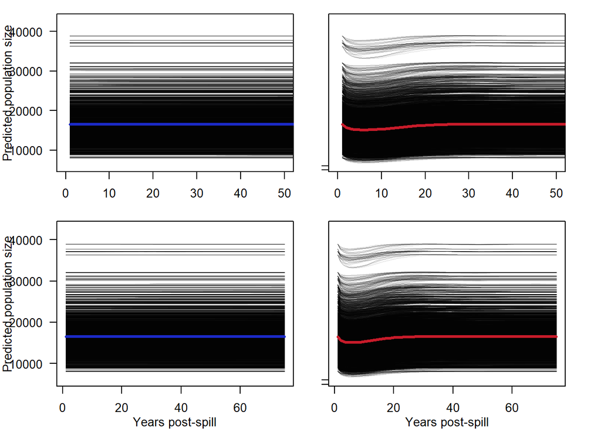

```r
plotSims(simres)
```

Injury measures

```r
x <- getInjury(simres)
```

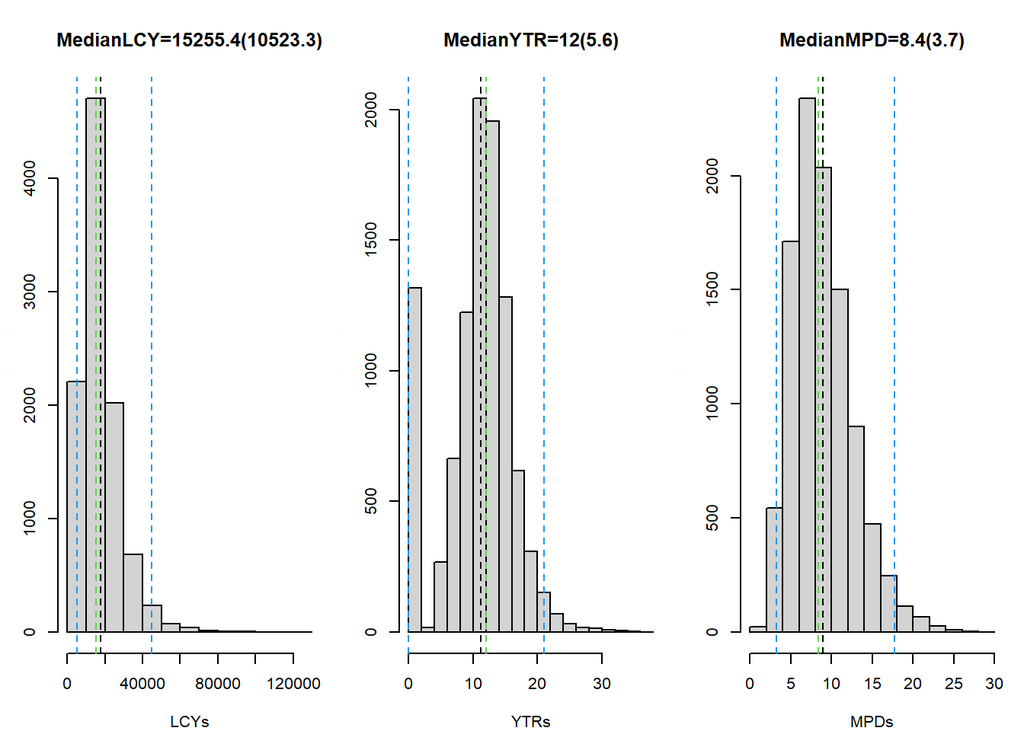

```r
colMeans(injury)
```

```
##          LCY          YTR          MPD
## 17714.767745    11.196700     8.899829
```

```r
apply(injury, 2, median)
```

```
##          LCY          YTR          MPD
## 15255.378214    12.000000     8.362931
```

Collect information to summary table

```r
sumres[sumres$Sp==Sp, 2:15]<-c(SpInfo$N, SpInfo$pe, SpInfo$LCY, SpInfo$MPD, SpInfo$YTR, IniPopSizes$N[IniPopSizes$Sp==Sp], IniPopSizes$Ne[IniPopSizes$Sp==Sp], IniPopSizes$Pe[IniPopSizes$Sp==Sp], mean(injury$LCY), mean(injury$MPD), mean(injury$YTR),  median(injury$LCY), median(injury$MPD), median(injury$YTR))
```

and collect information to injury summary table

```r
injuryCI[injuryCI$Sp==Sp, 2:10]<-c(median(injury$LCY), quantile(injury$LCY, probs=c(0.025,0.975)), median(injury$MPD), quantile(injury$MPD, probs = c(0.025, 0.975)), median(injury$YTR), quantile(injury$YTR,probs = c(0.025, 0.975)))
```

## 4.13 *Stenella coeruleoalba* (Scoe, striped dolphin)

```r
gc();Sp <- "Scoe"
```

```
##             used   (Mb) gc trigger    (Mb)   max used    (Mb)
## Ncells    689400   36.9    7634487   407.8   12858258   686.8
## Vcells 487631192 3720.4 1540598814 11753.9 1540595554 11753.9
```

```r
SpInfo <- getSpData(Sp)
load(file=paste0("InOutBySp/", SpInfo$folder, "/", Sp, "simres", ns, "Sim.RData"))
inputs$gd[inputs$Sp==Sp] <- SpInfo$gd
inputs$sr[inputs$Sp==Sp] <- with(SpInfo, mean(rbeta(10000, sra, srb)*(sru-srl)+srl))
```

Population trajectories

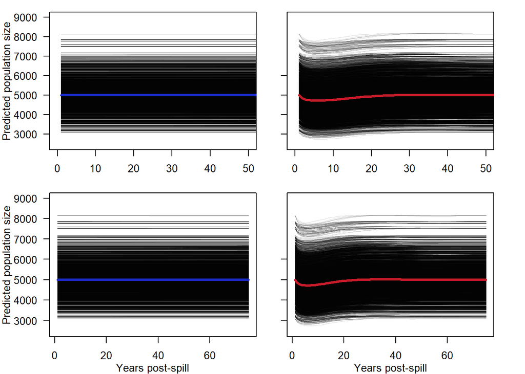

```r
plotSims(simres)
```

Injury measures

```r
x <- getInjury(simres)
```

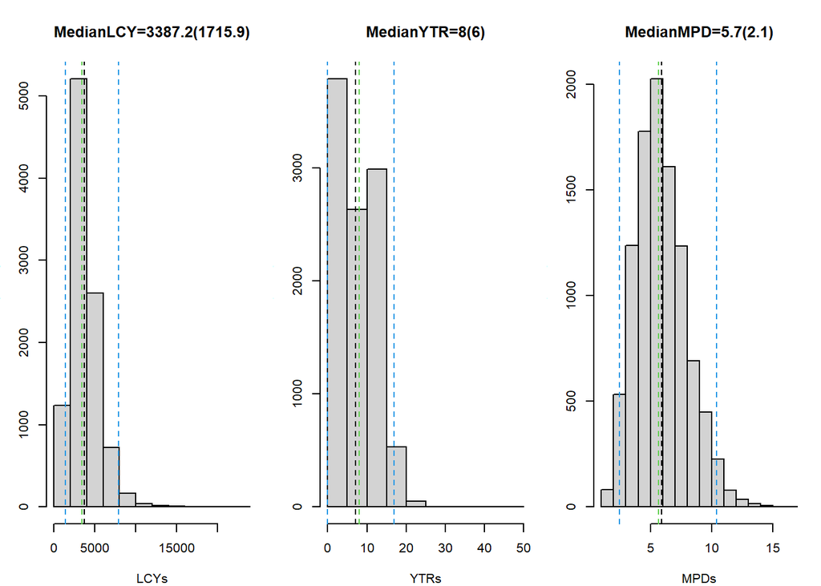

```r
colMeans(injury)
```

```
##         LCY         YTR         MPD
## 3715.207476    7.108100    5.883191
```

```r
apply(injury, 2, median)
```

```
##         LCY         YTR         MPD
## 3387.248043    8.000000    5.672636
```

Collect information to summary table

```r
sumres[sumres$Sp==Sp, 2:15]<-c(SpInfo$N, SpInfo$pe, SpInfo$LCY, SpInfo$MPD, SpInfo$YTR, IniPopSizes$N[IniPopSizes$Sp==Sp], IniPopSizes$Ne[IniPopSizes$Sp==Sp], IniPopSizes$Pe[IniPopSizes$Sp==Sp], mean(injury$LCY), mean(injury$MPD), mean(injury$YTR),  median(injury$LCY), median(injury$MPD), median(injury$YTR))
```

and collect information to injury summary table

```r
injuryCI[injuryCI$Sp==Sp, 2:10]<-c(median(injury$LCY), quantile(injury$LCY, probs=c(0.025,0.975)), median(injury$MPD), quantile(injury$MPD, probs = c(0.025, 0.975)), median(injury$YTR), quantile(injury$YTR,probs = c(0.025, 0.975)))
```

## 4.14 *Stenella frontalis* (Sfro, Atlantic spotted dolphin)

```r
gc();Sp <- "Sfro"
```

```
##             used   (Mb) gc trigger    (Mb)   max used    (Mb)
## Ncells    689439   36.9    5895287   314.9   12858258   686.8
## Vcells 541631383 4132.4 1540598814 11753.9 1540595554 11753.9
```

```r
SpInfo <- getSpData(Sp)
load(file=paste0("InOutBySp/", SpInfo$folder, "/", Sp, "simres", ns, "Sim.RData"))
inputs$gd[inputs$Sp==Sp] <- SpInfo$gd
inputs$sr[inputs$Sp==Sp] <- with(SpInfo, mean(rbeta(10000, sra, srb)*(sru-srl)+srl))
```

Population trajectories

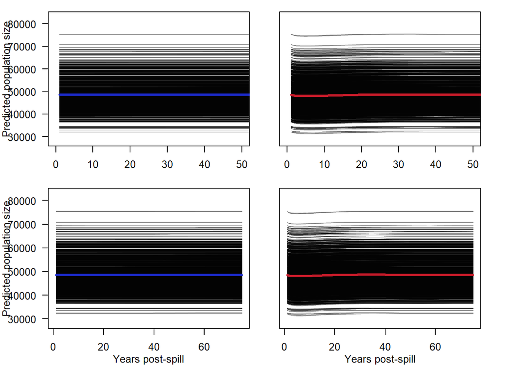

```r
plotSims(simres)
```

Injury measures

```r
x <- getInjury(simres)
```

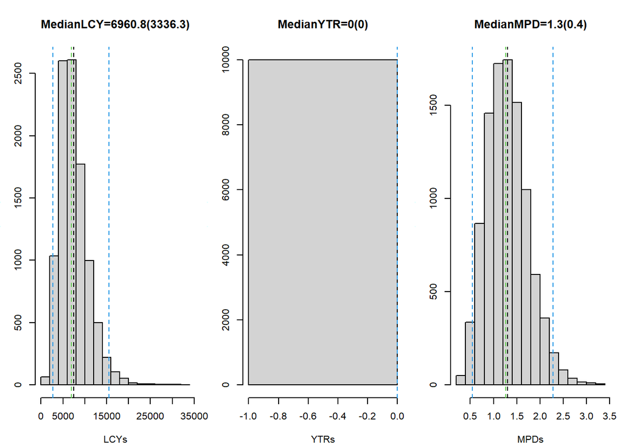

```r
colMeans(injury)
```

```
##         LCY         YTR         MPD
## 7509.270139    0.000000    1.296869
```

```r
apply(injury, 2, median)
```

```
##         LCY         YTR         MPD
## 6960.805094    0.000000    1.264394
```

Collect information to summary table

```r
sumres[sumres$Sp==Sp, 2:15]<-c(SpInfo$N, SpInfo$pe, SpInfo$LCY, SpInfo$MPD, SpInfo$YTR, IniPopSizes$N[IniPopSizes$Sp==Sp], IniPopSizes$Ne[IniPopSizes$Sp==Sp], IniPopSizes$Pe[IniPopSizes$Sp==Sp], mean(injury$LCY), mean(injury$MPD), mean(injury$YTR),  median(injury$LCY), median(injury$MPD), median(injury$YTR))
```

and collect information to injury summary table

```r
injuryCI[injuryCI$Sp==Sp, 2:10]<-c(median(injury$LCY), quantile(injury$LCY, probs=c(0.025,0.975)), median(injury$MPD), quantile(injury$MPD, probs = c(0.025, 0.975)), median(injury$YTR), quantile(injury$YTR,probs = c(0.025, 0.975)))
```

## 4.15 Beaked whales spp (Bwsp)

```r
gc();Sp <- "Bwsp"
```

```
##             used   (Mb) gc trigger    (Mb)   max used    (Mb)
## Ncells    689442   36.9    5630306   300.7   12858258   686.8
## Vcells 541631504 4132.4 1540598814 11753.9 1540595554 11753.9
```

```r
SpInfo <- getSpData(Sp)
load(file=paste0("InOutBySp/", SpInfo$folder, "/", Sp, "simres", ns, "Sim.RData"))
inputs$gd[inputs$Sp==Sp] <- SpInfo$gd
inputs$sr[inputs$Sp==Sp] <- with(SpInfo, mean(rbeta(10000, sra, srb)*(sru-srl)+srl))
```

Population trajectories

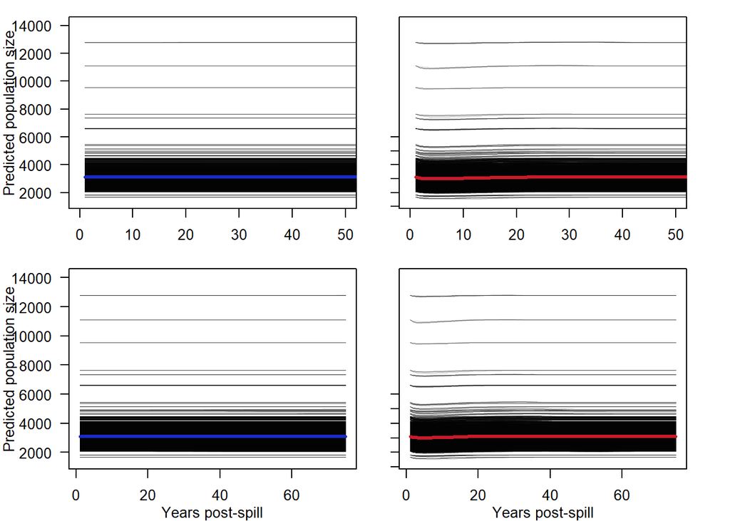

```r
plotSims(simres)
```

Injury measures

```r
x <- getInjury(simres)
```

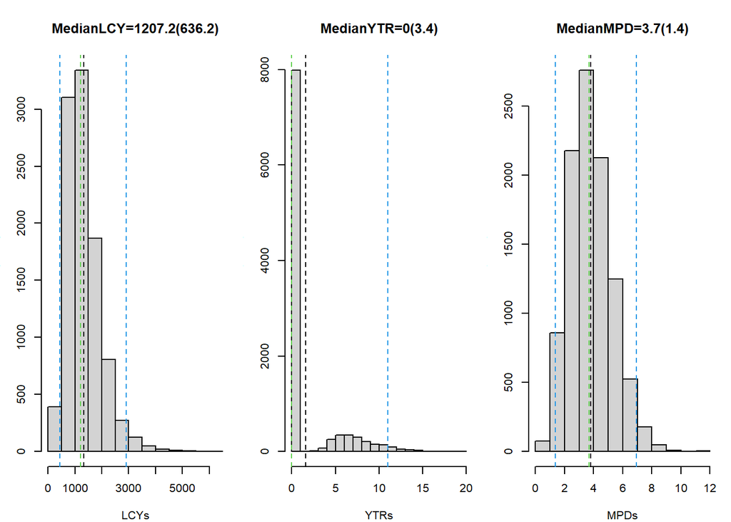

```r
colMeans(injury)
```

```
##         LCY         YTR         MPD
## 1320.899319    1.592200    3.816632
```

```r
apply(injury, 2, median)
```

```
##         LCY         YTR         MPD
## 1207.184847    0.000000    3.682783
```

Collect information to summary table

```r
sumres[sumres$Sp==Sp, 2:15]<-c(SpInfo$N, SpInfo$pe, SpInfo$LCY, SpInfo$MPD, SpInfo$YTR, IniPopSizes$N[IniPopSizes$Sp==Sp], IniPopSizes$Ne[IniPopSizes$Sp==Sp], IniPopSizes$Pe[IniPopSizes$Sp==Sp], mean(injury$LCY), mean(injury$MPD), mean(injury$YTR),  median(injury$LCY), median(injury$MPD), median(injury$YTR))
```

and collect information to injury summary table

```r
injuryCI[injuryCI$Sp==Sp, 2:10]<-c(median(injury$LCY), quantile(injury$LCY, probs=c(0.025,0.975)), median(injury$MPD), quantile(injury$MPD, probs = c(0.025, 0.975)), median(injury$YTR), quantile(injury$YTR,probs = c(0.025, 0.975)))
```